# International Recruitment Analytics for 2022 to May 2023

# Recruitment Agency Analysis:

```python
df["Agency"].value_counts()
```

```
Mokhtar       349
Almouwasat     68
Sidra          33
Alweroud       29
AlKhobraa      24
Elmona         19
JobCare        17
Pioneer        15
Aljazzera      14
Safar          13
Albalid        12
KNH             9
Asoul           7
Madaen          5
Referral        4
None            2
Dr.shokry       1
Name: Agency, dtype: int64
```

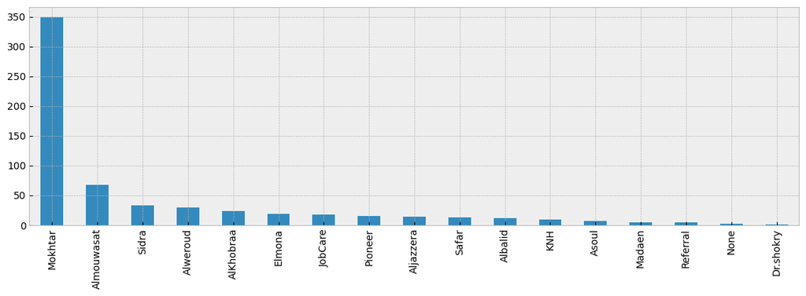

```python
# Agency Collected bar.
Agency_num = df["Agency"].value_counts()
Agency_num.plot(kind = 'bar', figsize=(14,4))
```

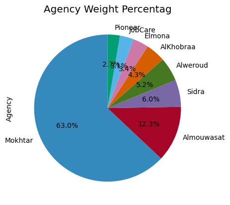

```python
# Agency Collected pie.
Agency_num.head(8).plot(kind='pie', title='Agency Weight Percentag', startangle=90, autopct='%1.1f%%');
```

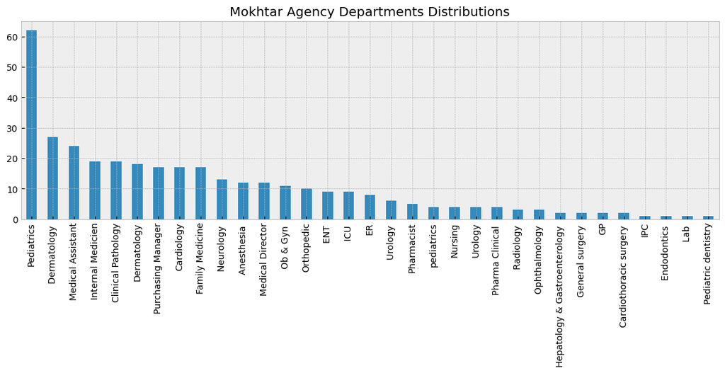

```python
#dividing the Agencies to top 5 Agency according to Colected Rate and defind departments rates.
Mokhtar = df.Agency == 'Mokhtar'
Almouwasat = df.Agency == 'Almouwasat'
Sidra = df.Agency == 'Sidra'
Alweroud = df.Agency == 'Alweroud'
AlKhobraa = df.Agency == 'AlKhobraa'
# Mokhtar Agency Analysis:
Mokhtar_Dep = (df[Mokhtar]['Department'].value_counts())
Mokhtar_Dep.plot(kind = 'bar', title = ("Mokhtar Agency Departments Distributions"), figsize=(14,4))
```

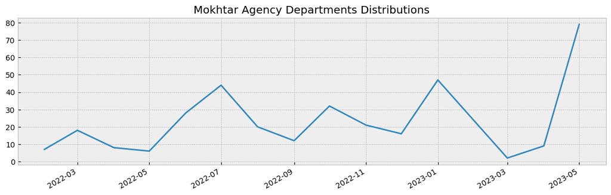

```python
# Mokhtar Agency Collected Timeline:
Mokhtar_Dep_time = (df[Mokhtar]['Month'].value_counts())
Mokhtar_Dep_time.plot(kind = 'line', title = ("Mokhtar Agency Departments Distributions"), figsize=(14,4))
```

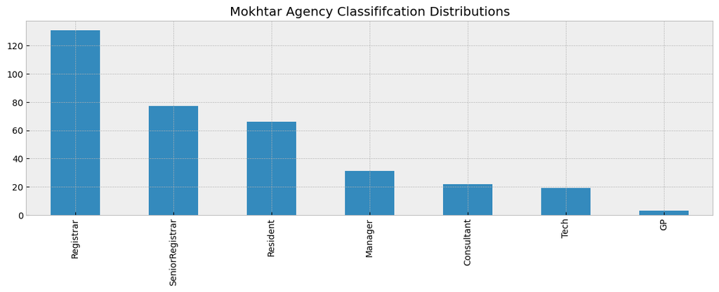

```python
# Mokhtar Agency Collected Classififcation:
Mokhtar_Class = (df[Mokhtar]['Classification'].value_counts())
Mokhtar_Class.plot(kind = 'bar', title = ("Mokhtar Agency Classififcation Distributions"), figsize=(14,4))
```

```
Interviewed    143
Cancelled       16
Postponed        3
Name: Interview_Status, dtype: int64
```

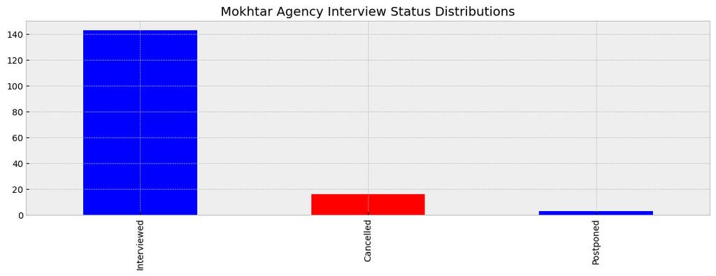

```python
# Mokhtar Agency Interview Status responses:
Mokhtar_Inter = (df[Mokhtar]['Interview_Status'].value_counts()).head(3)
print (Mokhtar_Inter)
Mokhtar_Inter.plot(kind = 'bar', color = ("Blue", "Red"), title = ("Mokhtar Agency Interview Status Distributions"), figsize=(14,4))
```

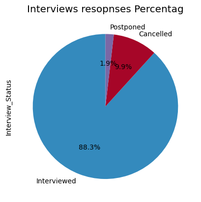

```python
# Mokhtar angency Interviews resopnses Percentag.
Mokhtar_Inter.plot(kind='pie', title='Interviews resopnses Percentag', startangle=90, autopct='%1.1f%%');
```

```
Sent    46
Name: Offer, dtype: int64
Accepted    23
Rejected    17
Name: Offer_Response, dtype: int64
```

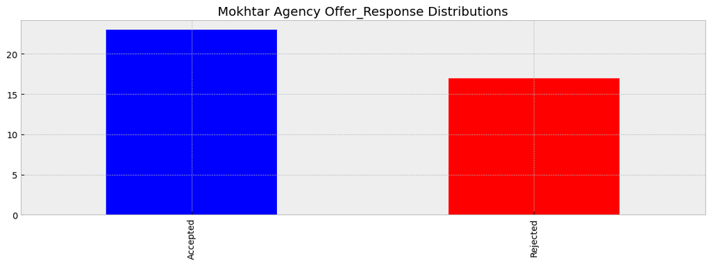

```python
# Mokhtar Agency Collected Offer sent & Offers responses:
Mokhtar_Offer = (df[Mokhtar]['Offer'].value_counts())
print (Mokhtar_Offer)
Mokhtar_Offer_res = (df[Mokhtar]['Offer_Response'].value_counts()).head(2)
print (Mokhtar_Offer_res)
Mokhtar_Offer_res.head(2).plot(kind = 'bar', color = ("Blue", "Red"), title = ("Mokhtar Agency Offer_Response Distributions"), figsize=(14,4))
```

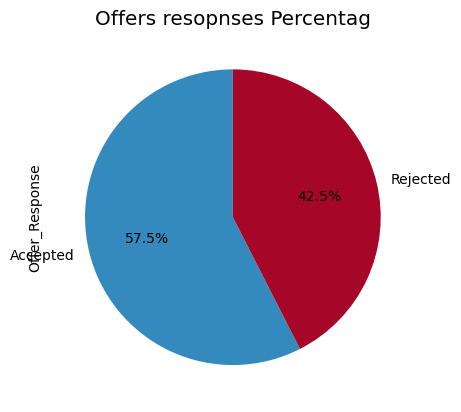

```python
# Mokhtar angency Offers resopnses Percentag.
Mokhtar_Offer_res.plot(kind='pie', title='Offers resopnses Percentag', startangle=90, autopct='%1.1f%%');
```

```python
# Mokhtar Screening Accuarcy Ratio:
Mokhtar_coll1 = (df[Mokhtar]["Agency"].value_counts())
Mokhtar_Inter1 = (df[Mokhtar]['Interview_Status'].value_counts()).head(1)
inter1 = sum(Mokhtar_Inter1)
Screen = sum(Mokhtar_coll1)
Mokhtar_Accuracy_Screen = (inter1/Screen*100)
print (Mokhtar_Accuracy_Screen)
```

```
40.97421203438395
```

```python
# Mokhtar Recruitment Accuarcy Ratio:
Mokhtar_Inter1 = (df[Mokhtar]['Interview_Status'].value_counts()).head(1)
Mokhtar_Offer_res1 = (df[Mokhtar]['Offer_Response'].value_counts()).head(1)
inter1 = sum(Mokhtar_Inter1)
off1 = sum(Mokhtar_Offer_res1)
Mokhtar_Accuracy = (off1/inter1*100)
print (Mokhtar_Accuracy)
```

```
16.083916083916083
```

```python
Mokhtar_all_Accu = (Mokhtar_Accuracy_Screen, Mokhtar_Accuracy)
print (Mokhtar_all_Accu)
```

```
(40.97421203438395, 16.083916083916083)
```

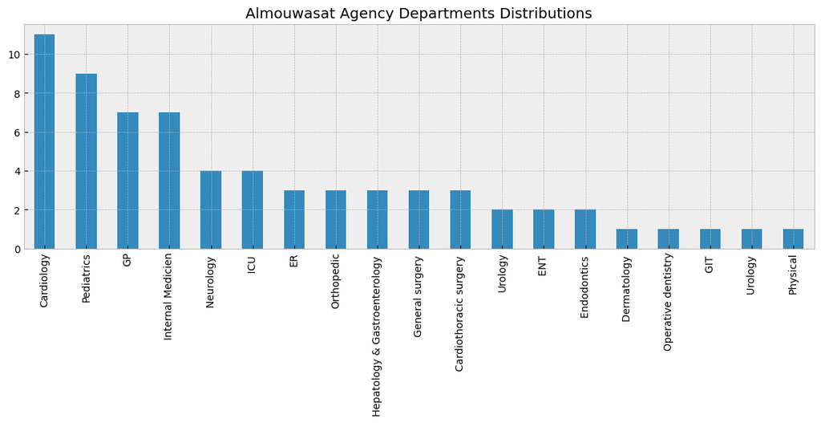

```python
# Almouwasat Agency Analysis:
Almouwasat_Dep = (df[Almouwasat]['Department'].value_counts())
Almouwasat_Dep.plot(kind = 'bar', title = ("Almouwasat Agency Departments Distributions"), figsize=(14,4))
```

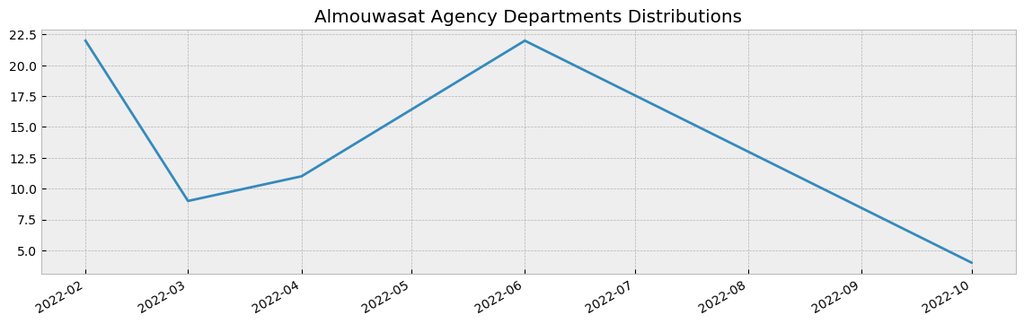

```python
# Almouwasat Agency Collected Timeline:
Almouwasat_Dep_time = (df[Almouwasat]['Month'].value_counts())
Almouwasat_Dep_time.plot(kind = 'line', title = ("Almouwasat Agency Departments Distributions"), figsize=(14,4))
```

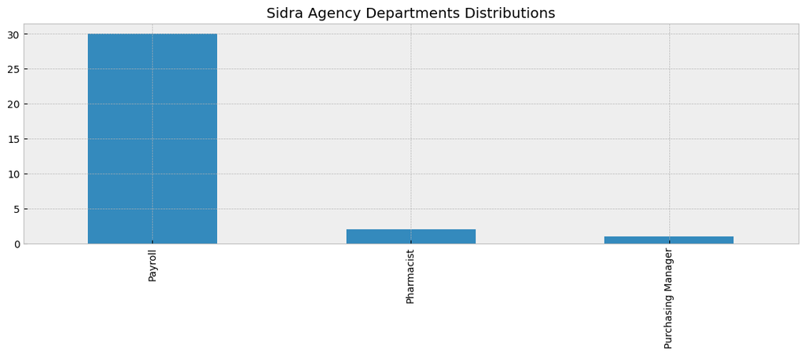

```python
# Sidra Agency Analysis:
Sidra_Dep = (df[Sidra]['Department'].value_counts())
Sidra_Dep.plot(kind = 'bar', title = ("Sidra Agency Departments Distributions"), figsize=(14,4))
```

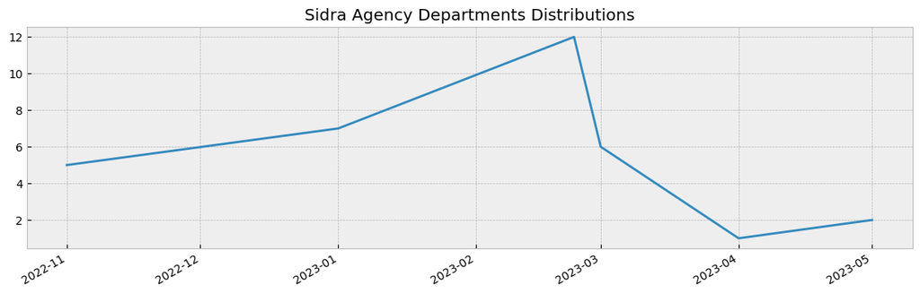

```python
# Sidra Agency Collected Timeline:
Sidra_Dep_time = (df[Sidra]['Month'].value_counts())
Sidra_Dep_time.plot(kind = 'line', title = ("Sidra Agency Departments Distributions"), figsize=(14,4))
```

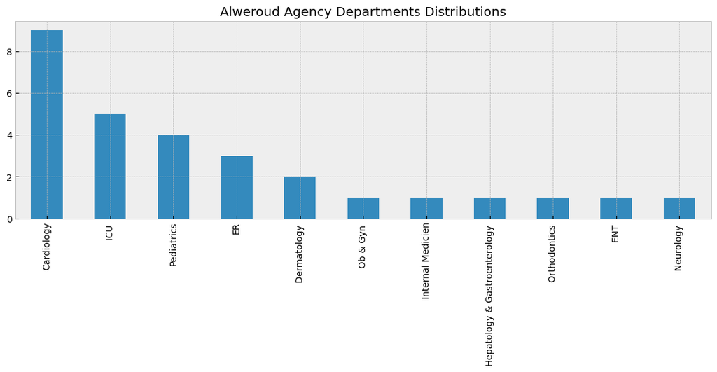

```python
# Alweroud Agency Analysis:
Alweroud_Dep = (df[Alweroud]['Department'].value_counts())
Alweroud_Dep.plot(kind = 'bar', title = ("Alweroud Agency Departments Distributions"), figsize=(14,4))
```

[figure not shown]

```python
# Alweroud Agency Collected Timeline:
Alweroud_Dep_time = (df[Alweroud]['Month'].value_counts())
Alweroud_Dep_time.plot(kind = 'line', title = ("Alweroud Agency Departments Distributions"), figsize=(14,4))
```

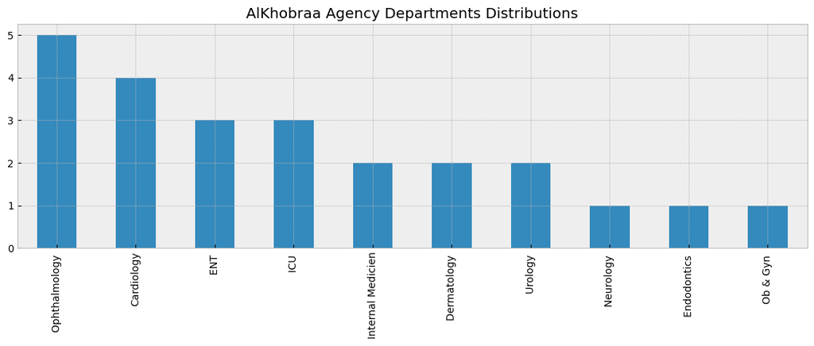

```python
# AlKhobraa Agency Analysis:
AlKhobraa_Dep = (df[AlKhobraa]['Department'].value_counts())
AlKhobraa_Dep.plot(kind = 'bar', title = ("AlKhobraa Agency Departments Distributions"), figsize=(14,4))
```

[figure not shown]

```python
# AlKhobraa Agency Collected Timeline:
AlKhobraa_Dep_time = (df[AlKhobraa]['Month'].value_counts())
AlKhobraa_Dep_time.plot(kind = 'line', title = ("AlKhobraa Agency Departments Distributions"), figsize=(14,4))
```

# Recruitment Report Conclusion

There is a slight improvement in structure Salary Scale, but work must be done to improve it and dictate where we are standing in market (Lag / Match / Lead).

NB: Most be redesign and create more intelligence benefits (Noncash) to attract employees, for smooth recruitment process and to reduction the rejection Percentage.

Most be speed up the Process.

Prefers Selection Candidate’s are finished most of process to avoid delay in recruitment time or candidates lost.

Most be put to agent’s & candidates timeline and target to recruit candidates and finished accommodation Process.

Most be selected before send to agents: is the agent the most accurate and attractive in this required position.

Most be after quarter analyzing all data and inform agents where is problem point.

# (Human Resources Specialist & Data Analyst Specialist)